# Reproducible Reseach / Peer Assessment 1

Cesar Bustos

Monday, July 13, 2015

Loading and preprocessing the data

```r
# Read the CSV file
data <- read.csv("activity.csv")
# Convert date column to date data type
data$date <- as.Date(data$date)
```

**What is mean total number of steps taken per day?**

For this part of the assignment, you can ignore the missing values in the dataset.

```
1. Calculate the total number of steps taken per day
2. If you do not understand the difference between a histogram and a barplot, research the difference between them. Make a histogram of the total number of steps taken each day
3. Calculate and report the mean and median of the total number of steps taken per day
```

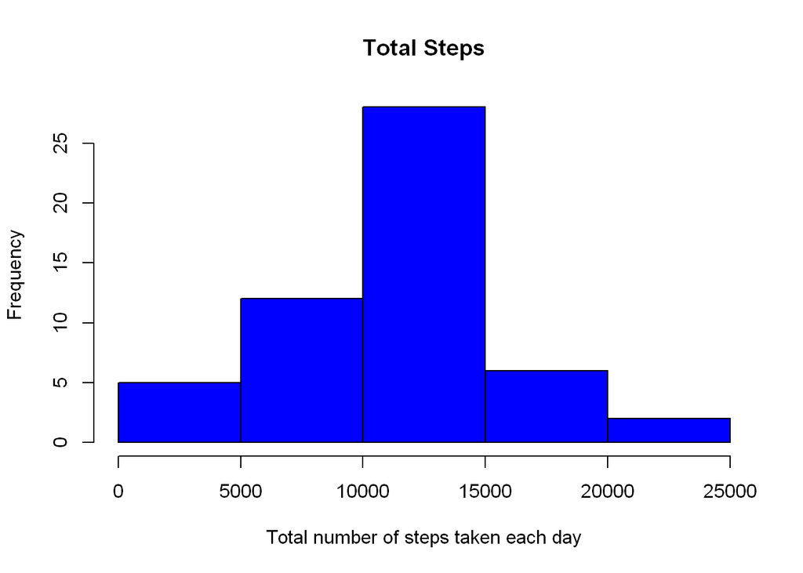

```r
##Eliminate the na values
total_steps <- aggregate(steps ~ date, data = data, sum, na.rm = TRUE)
##Plot the dataset
hist(total_steps$steps, main = "Total Steps", xlab="Total number of steps taken each day", col="blue")
```

```r
mean(total_steps$steps)
```

```
## [1] 10766.19
```

```r
median(total_steps$steps)
```

```
## [1] 10765
```

**What is the average daily activity pattern?**

```
1. Make a time series plot (i.e. type = "l") of the 5-minute interval (x-axis) and the average number of steps taken, averaged across all days (y-axis)
2. Which 5-minute interval, on average across all the days in the dataset, contains the maximum number of steps?
```

[figure not shown]

```r
library(ggplot2)
average <- aggregate(x=list(steps=data$steps), by=list(interval=data$interval), FUN=mean, na.rm=TRUE)
ggplot(data=average, aes(x=interval, y=steps)) + geom_line() +
  xlab("# of step count") + ylab("5-minute Interval")
```

```r
average[which.max(average$steps),]
```

```
##     interval    steps
## 104      835 206.1698
```

**Imputing missing values**

Note that there are a number of days/intervals where there are missing values (coded as NA). The presence of missing days may introduce bias into some calculations or summaries of the data.

```
1. Calculate and report the total number of missing values in the dataset (i.e. the total number of rows with NAs)
```

```r
##Finding missing values
missing_values <- is.na(data$steps)
## 2304 NAs rows
table(missing_values)
```

```
## missing_values
## FALSE  TRUE
## 15264  2304
```

[output not shown]

```r
library(sqldf)
query <- sqldf('select d.*, a.steps as value
                from "average" as a
                join "data" d on d.interval=a.interval')
```

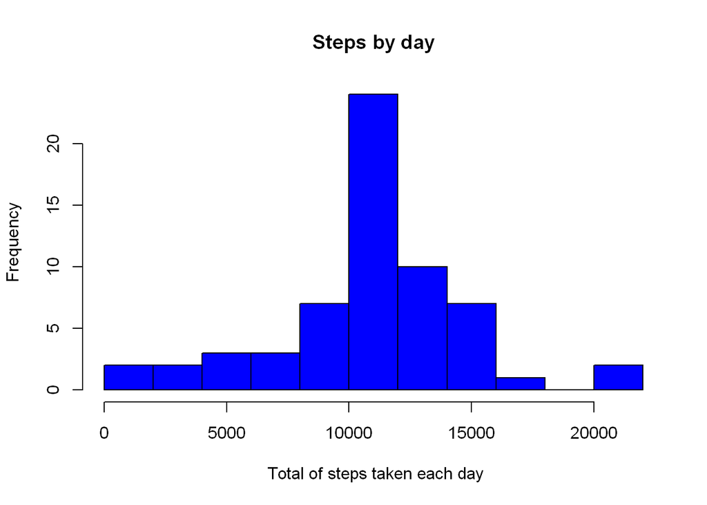

```r
query$steps[is.na(query$steps)] <- query$value[is.na(query$steps)]
##Query total steps
query_ts <- as.integer (sqldf('select sum(steps)
                     from query'))
##Query total steps by day
query_tsbd <- sqldf('select date, sum(steps) as steps_by_day
                       from query
                   group by date')
query_final <- sqldf('select date, steps_by_day
                        from query_tsbd')
hist(query_final$steps_by_day, main= "Steps by day", breaks=10
                 , xlab=" Total of steps taken each day", col="blue")
```

```r
mean_steps   <- query_ts / NROW(query_tsbd)
mean_steps
```

```
## [1] 10766.18
```

**Are there differences in activity patterns between weekdays and weekends?**

For this part the weekdays() function may be of some help here. Use the dataset with the filled in missing values for this part.

1. Create a new factor variable in the dataset with two levels - “weekday” and “weekend” indicating whether a given date is a weekday or weekend day.
2. Make a panel plot containing a time series plot (i.e. type = “l”) of the 5-minute interval (x-axis) and the average number of steps taken, averaged across all weekday days or weekend days (y-axis). See the README file in the GitHub repository to see an example of what this plot should look like using simulated data.

```r
query$weektime <- as.factor(ifelse(weekdays(query_final$date) %in%
                          c("Sábado", "Domingo"), "weekend", "weekday"))
query2 <- sqldf('select interval, avg(steps) as avg_steps,  weektime
                  from query
              group by interval, weektime
               ')
library("lattice")
```

[figure not shown]

```r
graphics <- xyplot(avg_steps ~ interval | factor(weektime), data=query2,
                   type = 'l', main="Hola", xlab="Hola2", ylab="Hola3", grid ="TRUE")
graphics
```